# Week 9, Lab Part 1: MLR cont.

Hannah Brady

11/30/2020

## Step 1: Attach packages and look at penguins

In console did View(penguins).

## Step 2: Reminder visual data exploration

Use ggpairs to look at relationships of all variables.

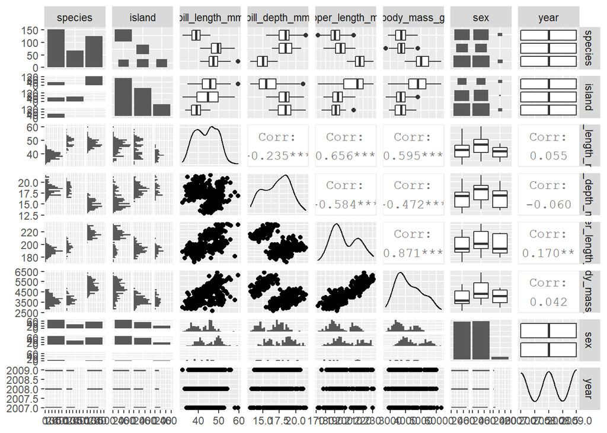

```r
penguins %>%
  ggpairs()
```

```r
# whoa that's overwhelming
```

Parse it down to make it easier to understand.

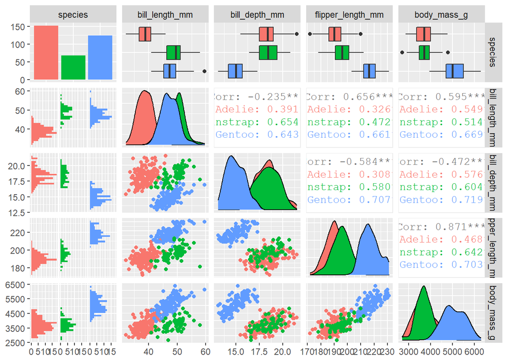

```r
penguins %>%
  select(species, bill_length_mm:body_mass_g) %>%
  ggpairs(aes(color = species))
```

Within groups between my different quantitative variables, it looks like a linear relationship makes sense.

### Determining non-collinearity

Scatterplots show that nothing is too highly correlated. The overall coreelation is shown to be 0.871

Highest correlation is Gentoo body_mass_g by bill_depth_mm at 0.719. Still not crazy high. Nothing is highly correlated, would not be overfitting model to add any variable based on collinearity.

Seems like multiple linear regression is a good option.

## Build a few different models

```r
lm1 <- lm(body_mass_g ~ flipper_length_mm + species, data = penguins)
lm1
```

```
##
## Call:
## lm(formula = body_mass_g ~ flipper_length_mm + species, data = penguins)
##
## Coefficients:
##       (Intercept)  flipper_length_mm   speciesChinstrap      speciesGentoo
##          -4031.48              40.71            -206.51             266.81
```

```r
lm2 <- lm(body_mass_g ~ flipper_length_mm + species + sex, data = penguins)
lm2
```

```
##
## Call:
## lm(formula = body_mass_g ~ flipper_length_mm + species + sex,
##     data = penguins)
##
## Coefficients:
##       (Intercept)  flipper_length_mm   speciesChinstrap      speciesGentoo
##           -365.82              20.02             -87.63             836.26
##           sexmale
##            530.38
```

```r
lm3 <- lm(body_mass_g ~ flipper_length_mm + species + sex + bill_length_mm, data = penguins)
lm3
```

```
##
## Call:
## lm(formula = body_mass_g ~ flipper_length_mm + species + sex +
##     bill_length_mm, data = penguins)
##
## Coefficients:
##       (Intercept)  flipper_length_mm   speciesChinstrap      speciesGentoo
##           -759.06              17.85            -291.71             707.03
##           sexmale     bill_length_mm
##            465.40              21.63
```

```r
lm4 <- lm(body_mass_g ~ flipper_length_mm + species + sex + bill_length_mm + island, data = penguins)
lm4
```

```
##
## Call:
## lm(formula = body_mass_g ~ flipper_length_mm + species + sex +
##     bill_length_mm + island, data = penguins)
##
## Coefficients:
##       (Intercept)  flipper_length_mm   speciesChinstrap      speciesGentoo
##           -785.56              18.14            -293.05             676.10
##           sexmale     bill_length_mm        islandDream    islandTorgersen
##            463.64              21.53             -23.24             -47.21
```

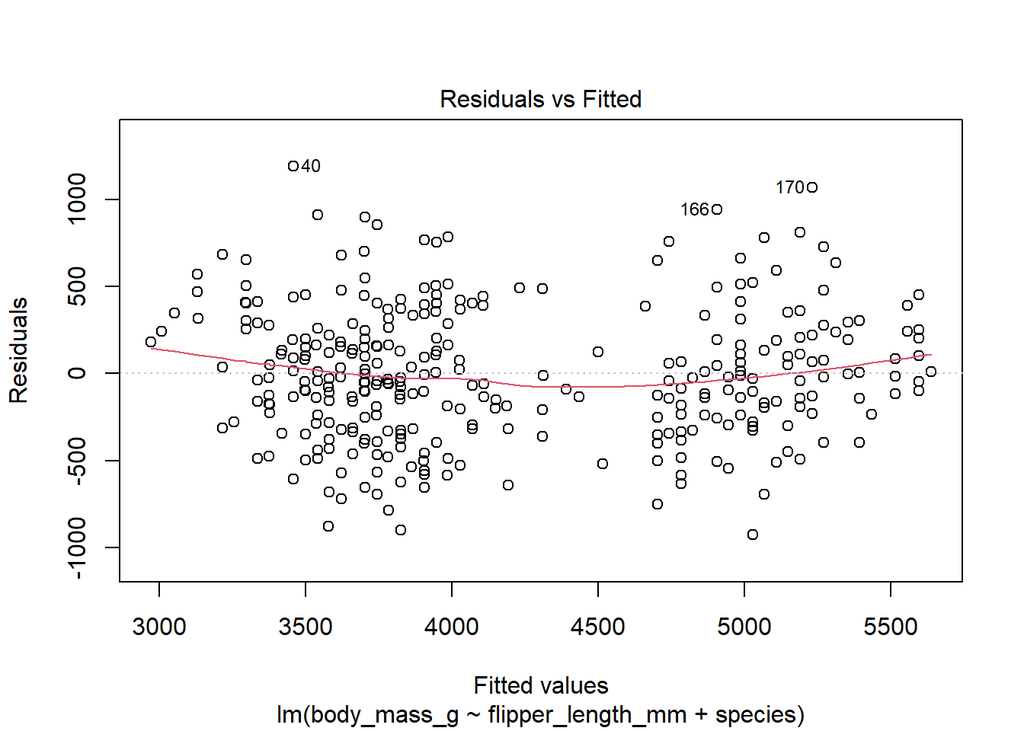

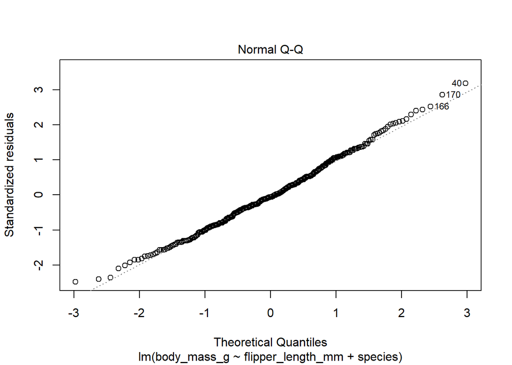

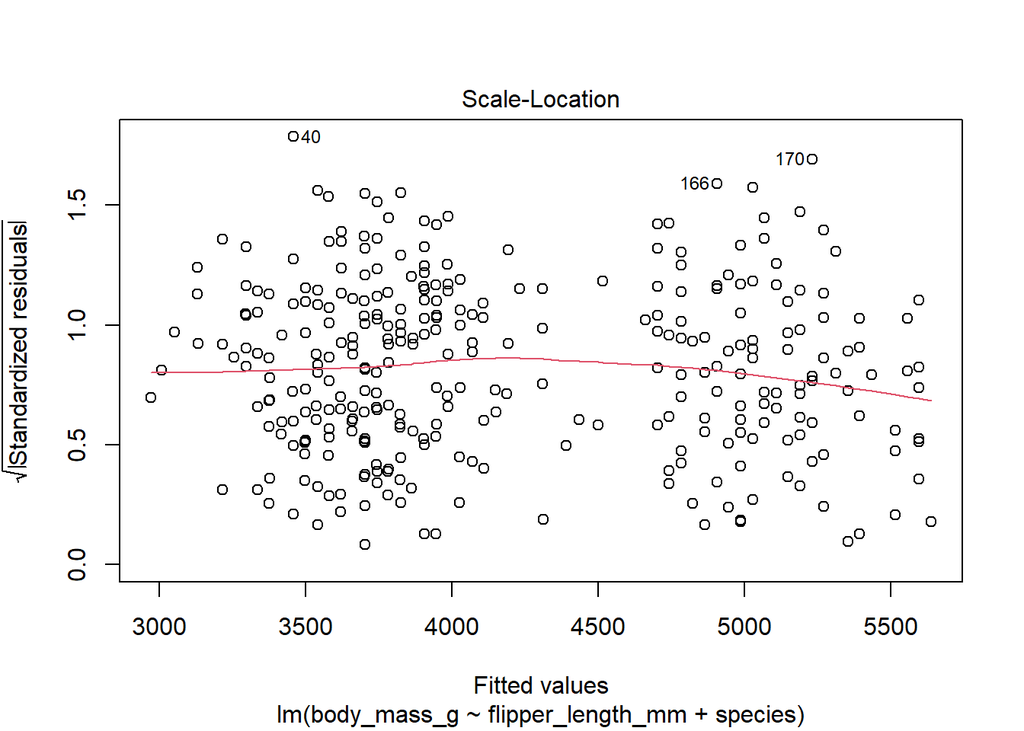

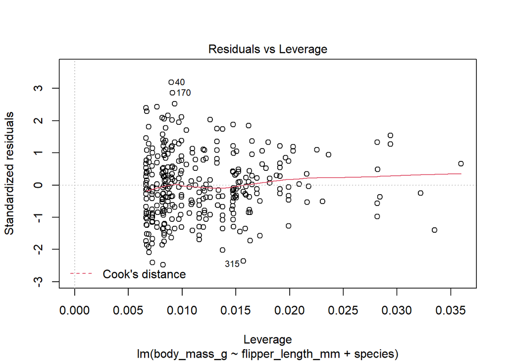

```r
 plot(lm1) # No concerns
```

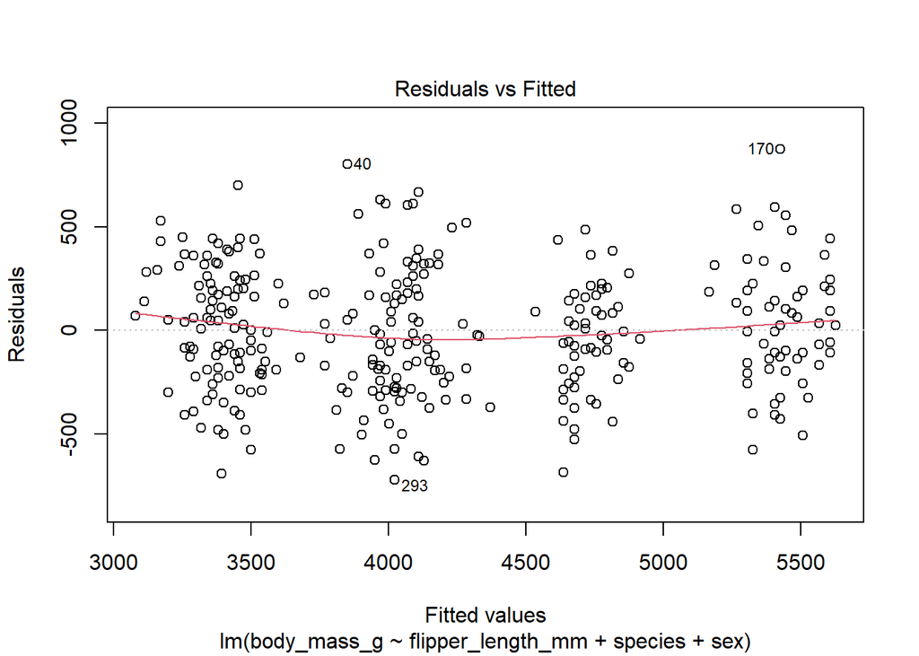

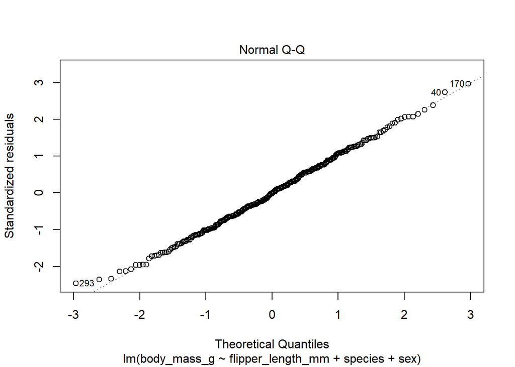

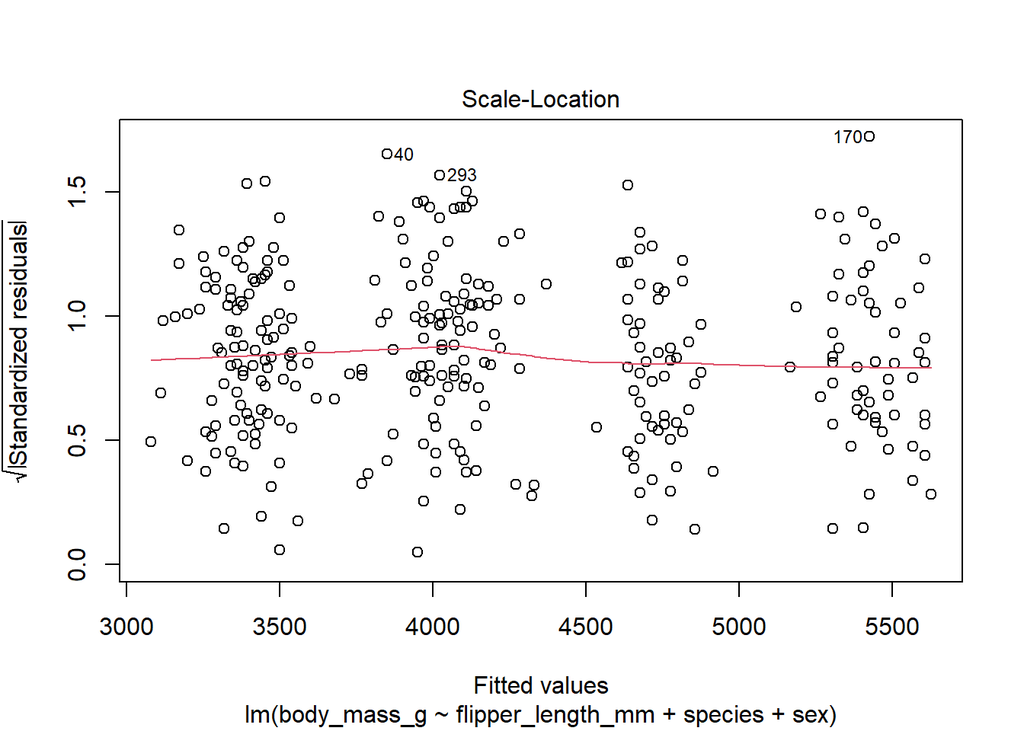

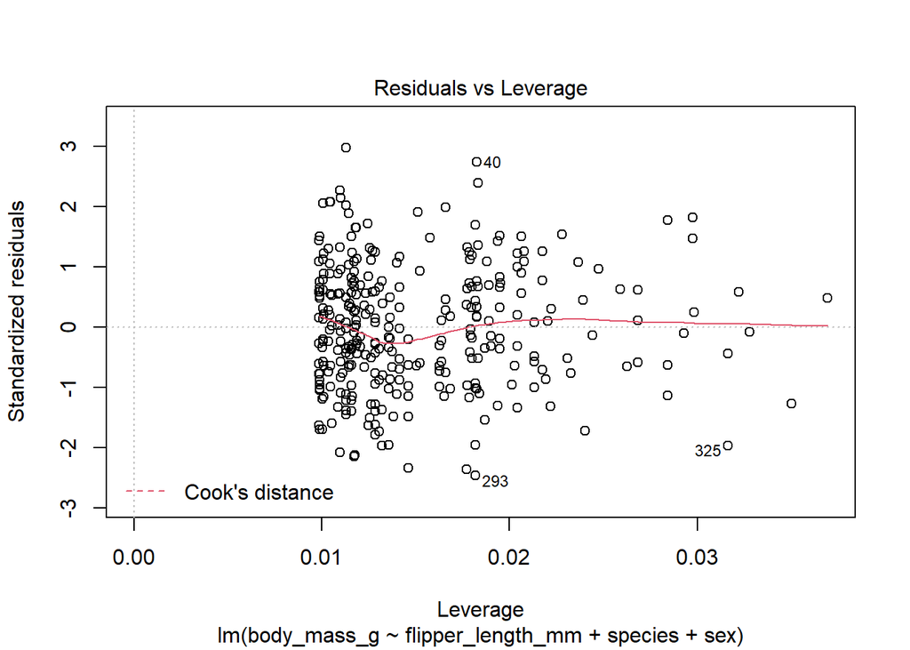

```r
 plot(lm2) # No concerns
```

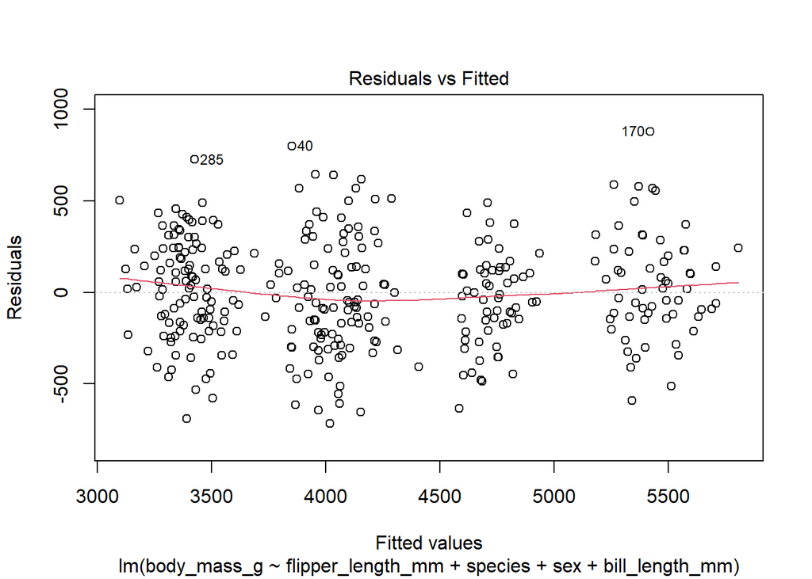

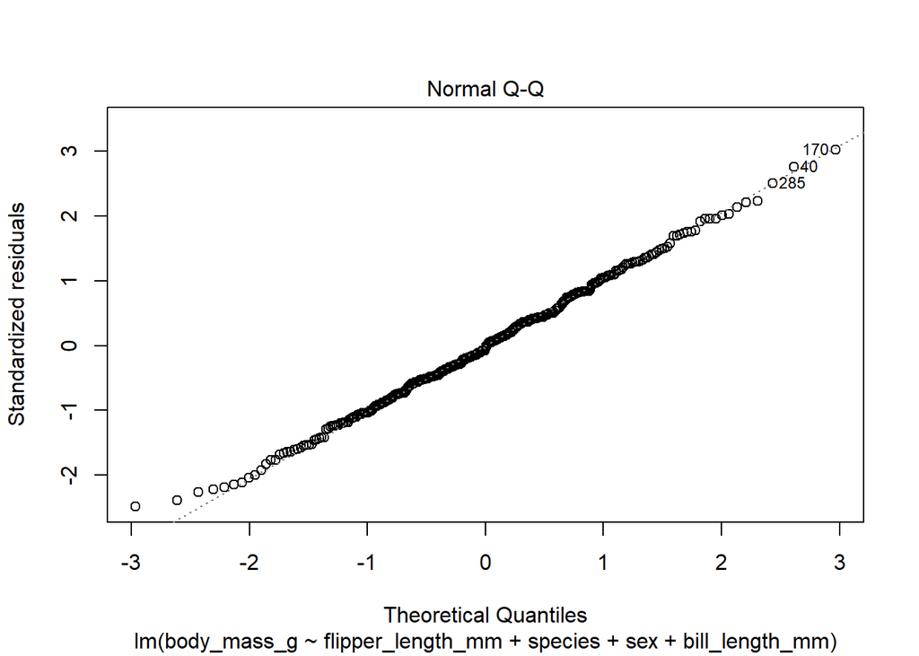

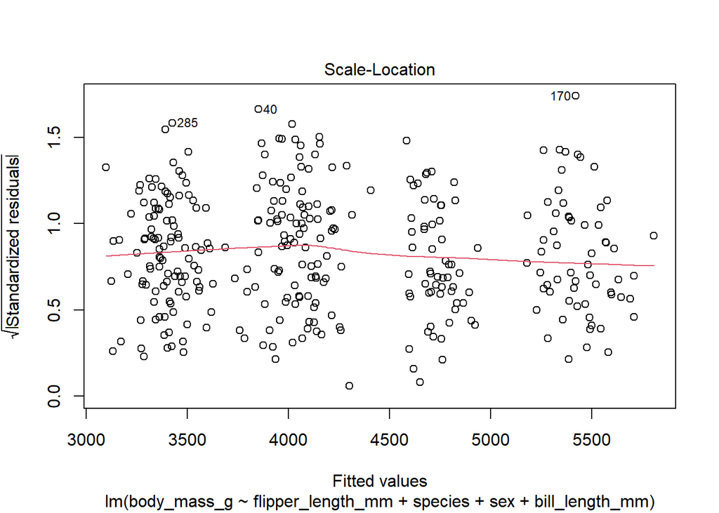

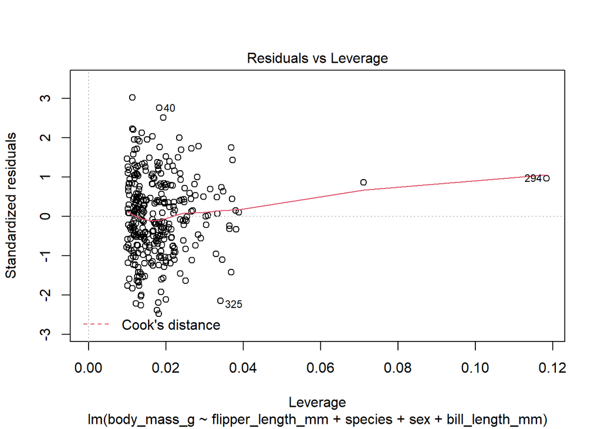

```r
 plot(lm3) # No concerns
```

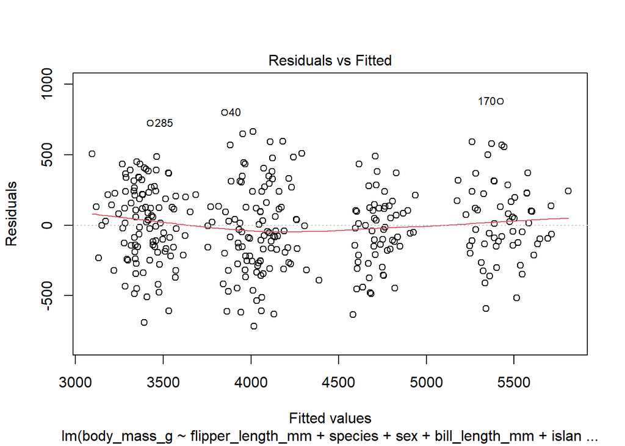

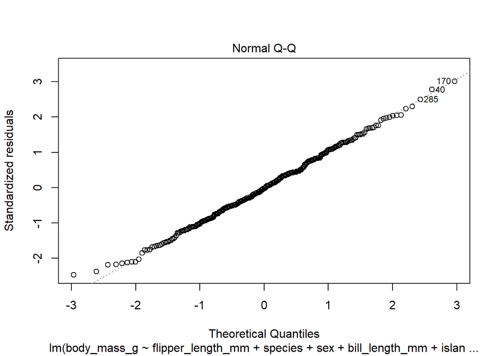

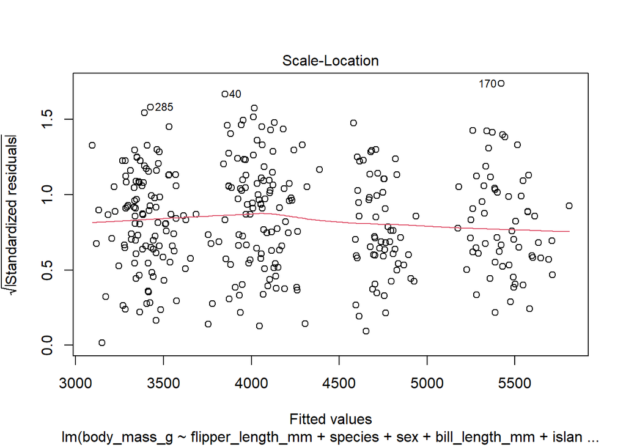

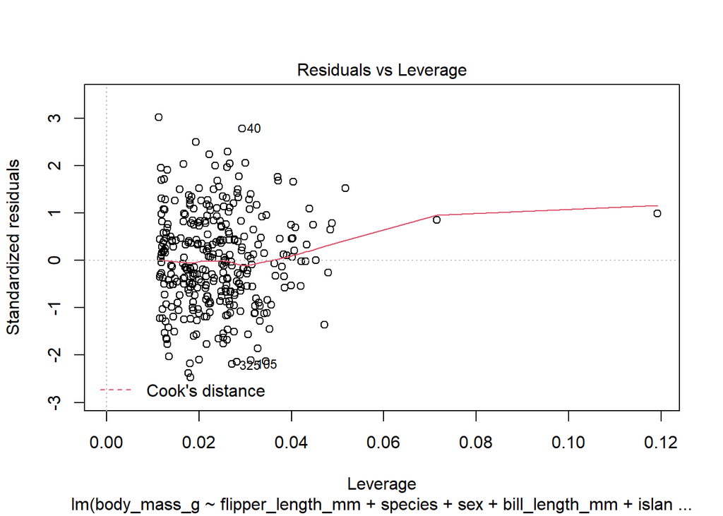

```r
 plot(lm4) # No concerns
```

AIC

Penalizes addition of more variables and lets you know if improved model fit was worth it.

Lower the value of the AIC - the better.

# Find AIC for all models

No packages needed, part of base R’s stats package

```r
AIC(lm1)
```

```
## [1] 5031.523
```

```r
# Value by itself, means nothing! Only useful when comparing permutations of a model.
AIC(lm2)
```

```
## [1] 4740.774
```

```r
AIC(lm3)
```

```
## [1] 4733.574
```

```r
AIC(lm4)
```

```
## [1] 4736.979
```

AIC loved adding sex. Didn’t like addition of island in lm4 - not worth it! If only using AIC value as metric - lowest AIC value was for lm3, indicating that is the best balance of model fit and model complexity.

Recall that it is only part tho of how we evaluate and make models. Think about what we already know, bg research, conceptually.

## Use stargazer for a table with multiple model outputs

```r
stargazer(lm1, lm2, lm3, lm4, type = "html")
```

|  | *Dependent variable:* |  |  |  |
| --- | --- | --- | --- | --- |
|  | body_mass_g |  |  |  |
|  | (1) | (2) | (3) | (4) |
| flipper_length_mm | 40.705*** | 20.025*** | 17.847*** | 18.138*** |
|  | (3.071) | (2.846) | (2.902) | (2.933) |
| speciesChinstrap | -206.510*** | -87.634* | -291.711*** | -293.045*** |
|  | (57.731) | (46.347) | (81.502) | (89.455) |
| speciesGentoo | 266.810*** | 836.260*** | 707.028*** | 676.103*** |
|  | (95.264) | (85.185) | (94.359) | (104.019) |
| sexmale |  | 530.381*** | 465.395*** | 463.640*** |
|  |  | (37.810) | (43.081) | (43.292) |
| bill_length_mm |  |  | 21.633*** | 21.528*** |
|  |  |  | (7.148) | (7.183) |
| islandDream |  |  |  | -23.244 |
|  |  |  |  | (59.413) |
| islandTorgersen |  |  |  | -47.212 |
|  |  |  |  | (61.909) |
| Constant | -4,031.477*** | -365.817 | -759.064 | -785.564 |
|  | (584.151) | (532.050) | (541.377) | (545.027) |
| Observations | 342 | 333 | 333 | 333 |
| R<sup>2</sup> | 0.783 | 0.867 | 0.871 | 0.871 |
| Adjusted R<sup>2</sup> | 0.781 | 0.865 | 0.869 | 0.868 |
| Residual Std. Error | 375.535 (df = 338) | 295.565 (df = 328) | 291.955 (df = 327) | 292.590 (df = 325) |
| F Statistic | 405.693*** (df = 3; 338) | 534.024*** (df = 4; 328) | 439.680*** (df = 5; 327) | 312.778*** (df = 7; 325) |
| *Note:* | p<0.1; p<0.05; p<0.01 |  |  |  |